# libwwz demo 1: Sinusoid with Randomly Removed Data

This notebook will demonstrate a basic example of using libwwz specified in the following list.

- Generate a timestamp
- Generate a sinusoid of a single frequency
- Remove data randomly from both the sinusoid and timestamp
- Use libwwz to compute the WWZ and WWA using 'linear' method
- Plot the computed WWZ and WWA

```python
# Import dependencies
import numpy as np
import matplotlib.pyplot as plt
import libwwz
import libwwz.plot_methods as libplot

# Edit default plot parameters
plt.rcParams["figure.figsize"] = [13, 5]
plt.rcParams.update({'font.size': 16})
```

## Let's make some data to analyze...

The data to be analyzed:

- Sinusoid with 4 Hz frequency and amplitude of 10
- Sample frequency of 800 Hz
- Total duration of 4 seconds

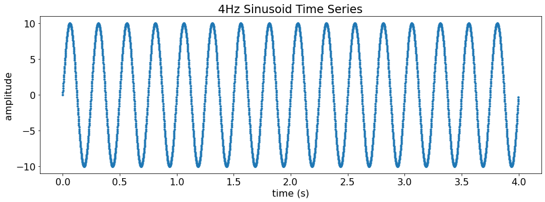

```python
# Initialize start_time, end_time, amplitude, and sample_frequency for our demo data.
start_time = 0
end_time = 4
amplitude = 10
sample_frequency = 800

# Use the above parameters to generate a timestamp
timestamp = np.arange(start_time, end_time, 1/sample_frequency)

# Using the timestamp, let's make a sinusoid.
sine_4hz = amplitude * np.sin(timestamp * 4 * (2 * np.pi))

# Display the generatated signals
plt.plot(timestamp, sine_4hz, '.')

# Add titles, labels, and set layout
plt.title('4Hz Sinusoid Time Series')
plt.xlabel('time (s)')
plt.ylabel('amplitude')
plt.tight_layout()
```

## Now let's remove some of the points to create a unevenly sampled data...

We will be removing 90% of the data at random.

The seed is specified in order to ensure that the data points and timestamps are removed at the same location.

```python
# This is a method that removes a fraction of points from a dataset at random with the same seed
def remove_fraction_with_seed(data, fraction, seed=0):
    """
    removes a fraction of data at random with given seed.
    :param data: data to remove
    :param fraction: fraction to remove
    :param seed: seed for randomness
    :return: data with fraction removed
    """
    n_to_remove = int(len(data) * fraction)
    np.random.seed(seed)

    return np.delete(data, np.random.choice(np.arange(len(data)), n_to_remove, replace=False))
```

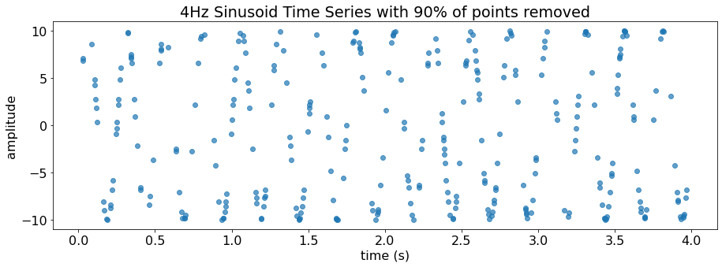

```python
# Let's remove 90% of points at the same timestamp using the above method...
timestamp_removed = remove_fraction_with_seed(timestamp, 0.9)
sine_4hz_removed = remove_fraction_with_seed(sine_4hz, 0.9)

# Display the unevenly sampled signal
plt.plot(timestamp_removed, sine_4hz_removed, 'o', alpha=0.7)

# Add titles, labels, and set layout
plt.title('4Hz Sinusoid Time Series with 90% of points removed')
plt.xlabel('time (s)')
plt.ylabel('amplitude')
plt.tight_layout()
```

## We got some data to look at, now to prep the libwwz...

These are the parameters to be used to compute the WWZ and WWA using the linear method.

The linear method sets the analyzed frequencies to be in equal steps. (This is the traditional method)

```python
# Select the size for the newly generated timestamps (tau), it should be less than the length of the given data.
# This will also limit the minimum possible frequecny
ntau = 80

# Set the low and high frequency bounds and steps to iterate
frequency_low = 0.5
frequency_high = 5.5
frequency_steps = 0.1

# Set the override to False (Setting to True will ignore the low and high frequency limitations)
override = False

# gather the frequency parameters into a list [freq_low, freq_high, freq_step, override]
frequency_parameters = [frequency_low, frequency_high, frequency_steps, override]

# We will then select the decay constant for our analyzing wavelet (negligible at < 0.2)
decay_constant = 0.0125

# Finally, we select to wether to run with parallization (recommend True)
parallel = True
```

## Plug n Chug...

```python
# Using the above settings, we will now compute the WWZ/WWA for the full timeseries and removed timeseries
wwt_4hz = libwwz.wwt(timestamps=timestamp,
                     magnitudes=sine_4hz,
                     time_divisions=ntau,
                     freq_params=frequency_parameters,
                     decay_constant=decay_constant,
                     method='linear',
                     parallel=parallel)

wwt_4hz_removed = libwwz.wwt(timestamps=timestamp_removed,
                             magnitudes=sine_4hz_removed,
                             time_divisions=ntau,
                             freq_params=frequency_parameters,
                             decay_constant=decay_constant,
                             method='linear',
                             parallel=parallel)
```

```
*** Starting Weighted Wavelet Z-transform ***

Pseudo sample frequency is  800.0
largest tau window is  0.051
17.53 seconds has passed to complete Weighted Wavelet Z-transform

*** Starting Weighted Wavelet Z-transform ***

Pseudo sample frequency is  80.964
largest tau window is  0.05
1.73 seconds has passed to complete Weighted Wavelet Z-transform
```

## Let's see the results...

We will plot the results using the plot methods available in the libwwz.

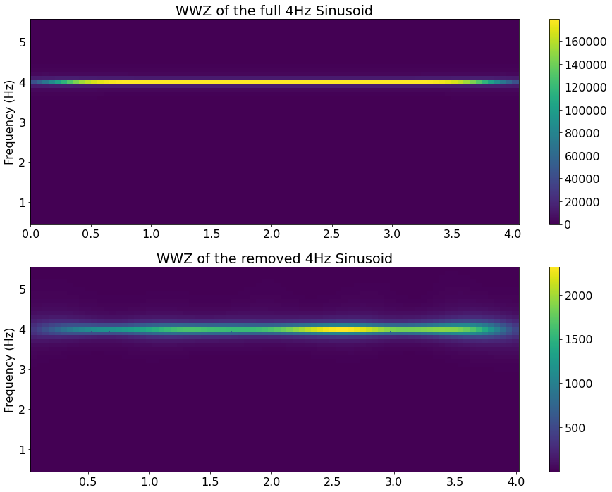

```python
# First we will look at WWZ for both full and removed data...
# WWZ is better at discerning the frequencies of the signal

fig, ax = plt.subplots(nrows=2, sharex=False, figsize=[13, 10])

libplot.linear_plotter(ax=ax[0],
                       TAU=wwt_4hz[0],
                       FREQ=wwt_4hz[1],
                       DATA=wwt_4hz[2])
ax[0].set_ylabel('Frequency (Hz)')
ax[0].set_title('WWZ of the full 4Hz Sinusoid')
ax[0].set_yticks([1, 2, 3, 4, 5])

libplot.linear_plotter(ax=ax[1],
                       TAU=wwt_4hz_removed[0],
                       FREQ=wwt_4hz_removed[1],
                       DATA=wwt_4hz_removed[2])
ax[1].set_ylabel('Frequency (Hz)')
ax[1].set_title('WWZ of the removed 4Hz Sinusoid')
ax[1].set_yticks([1, 2, 3, 4, 5])

# tight layout
plt.tight_layout()
```

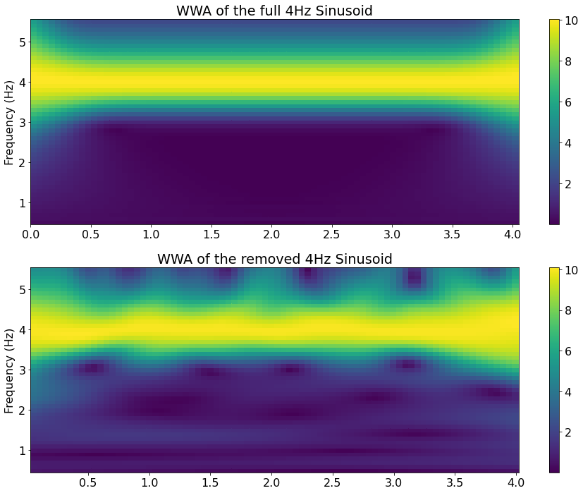

```python
# Next we will look at WWA for both full and removed data...
# WWA is better at discerning the amplitudes of the signal

fig, ax = plt.subplots(nrows=2, sharex=False, figsize=[13, 10])

libplot.linear_plotter(ax=ax[0],
                       TAU=wwt_4hz[0],
                       FREQ=wwt_4hz[1],
                       DATA=wwt_4hz[3])
ax[0].set_ylabel('Frequency (Hz)')
ax[0].set_title('WWA of the full 4Hz Sinusoid')
ax[0].set_yticks([1, 2, 3, 4, 5])

libplot.linear_plotter(ax=ax[1],
                       TAU=wwt_4hz_removed[0],
                       FREQ=wwt_4hz_removed[1],
                       DATA=wwt_4hz_removed[3])
ax[1].set_ylabel('Frequency (Hz)')
ax[1].set_title('WWA of the removed 4Hz Sinusoid')
ax[1].set_yticks([1, 2, 3, 4, 5])

# tight layout
plt.tight_layout()
```

## Let's look at the Effective Number for both full and removed signals...

Since Weighted Wavelet Z-Transform is a weighted projection, we use effective number instead of number of data points

```python
# The effective number for full data
print('The average Neff is :', int(wwt_4hz[5].mean()))
print('The median Neff is :', int(np.median(wwt_4hz[5])))
print('The min Neff is :', int(wwt_4hz[5].min()))
print('The max Neff is :', int(wwt_4hz[5].max()))
```

```
The average Neff is : 1113
The median Neff is : 862
The min Neff is : 259
The max Neff is : 3137
```

```python
# The effective number for removed data
print('The average Neff is :', int(wwt_4hz_removed[5].mean()))
print('The median Neff is :', int(np.median(wwt_4hz_removed[5])))
print('The min Neff is :', int(wwt_4hz_removed[5].min()))
print('The max Neff is :', int(wwt_4hz_removed[5].max()))
```

```
The average Neff is : 112
The median Neff is : 86
The min Neff is : 26
The max Neff is : 313
```